# Mixed effect model for batch correction - limma

Joyce Hsiao

2015-11-11

**Last updated:** 2015-11-11

**Code version:** 89061d40668f15cd1c752da1b1144203f564e684

## Objective

Compare per gene batch effect correction versus genewide batch effect correct using the [filtered data].

[filtered data](https://jdblischak.github.io/singleCellSeq/analysis/data-transformation.html)

## Setup

```r
source("functions.R")
library("limma")
library("edgeR")
```

```r
library(ggplot2)
theme_set(theme_bw(base_size = 16))
```

## Data preparation

Input quality single cells

```r
quality_single_cells <- read.table("../data/quality-single-cells.txt",
                                  header = TRUE,
                                  stringsAsFactors = FALSE)
str(quality_single_cells)
```

```
'data.frame':   567 obs. of  1 variable:
 $ NA19098.r1.A01: chr  "NA19098.r1.A02" "NA19098.r1.A04" "NA19098.r1.A05" "NA19098.r1.A06" ...
```

Input annotation

```r
anno <- read.table("../data/annotation.txt",
                    header = TRUE,
                    stringsAsFactors = FALSE)
anno_filter <- anno[ which(anno$sample_id %in% quality_single_cells[[1]]), ]
dim(anno_filter)
```

```
[1] 567   5
```

*Molecule counts

Input molecule counts.

```r
molecules <- read.table("../data/molecules.txt",
                          header = TRUE,
                          stringsAsFactors = FALSE)
dim(molecules)
```

```
[1] 18568   864
```

Filter cells.

```r
molecules_filter <- molecules[ , which(colnames(molecules) %in% quality_single_cells[[1]])]
dim(molecules_filter)
```

```
[1] 18568   567
```

Filter genes.

```r
molecules_cpm_mean <- rowMeans(cpm(molecules_filter, log = TRUE))
lower_exp_cutoff <- 2
genes_pass_filter <- rownames(molecules_filter)[molecules_cpm_mean > lower_exp_cutoff]
```

```r
overexpressed_rows <- apply(molecules_filter, 1, function(x) any(x >= 1024))
overexpressed_genes <- rownames(molecules_filter)[overexpressed_rows]
genes_pass_filter <- setdiff(genes_pass_filter, overexpressed_genes)
```

```r
molecules_filter <- molecules_filter[rownames(molecules_filter) %in% genes_pass_filter, ]
```

*Correct for collision probability

```r
molecules_collision <- -1024 * log(1 - molecules_filter / 1024)
```

*Molecules single cell endogeneous

```r
ercc_rows <- grepl("ERCC", rownames(molecules_filter))
molecules_cpm <- cpm(molecules_collision[!ercc_rows, ], log = TRUE)
```

*Linear transformation

```r
molecules_cpm_ercc <- cpm(molecules_collision[ercc_rows, ], log = TRUE)
ercc <- read.table("../data/expected-ercc-molecules.txt", header = TRUE,
                   stringsAsFactors = FALSE)
ercc <- ercc[ercc$id %in% rownames(molecules_cpm_ercc), ]
ercc <- ercc[order(ercc$id), ]
ercc$log2_cpm <- cpm(ercc$ercc_molecules_well, log = TRUE)
```

```r
molecules_cpm_trans <- molecules_cpm
molecules_cpm_trans[, ] <- NA
intercept <- numeric(length = ncol(molecules_cpm_trans))
slope <- numeric(length = ncol(molecules_cpm_trans))
for (i in 1:ncol(molecules_cpm_trans)) {
  fit <- lm(molecules_cpm_ercc[, i] ~ ercc$log2_cpm)
  intercept[i] <- fit$coefficients[1]
  slope[i] <- fit$coefficients[2]
  # Y = mX + b -> X = (Y - b) / m
  molecules_cpm_trans[, i] <- (molecules_cpm[, i] - intercept[i]) / slope[i]
}
dim(molecules_cpm_trans)
```

```
[1] 10564   567
```

## Remove unwanted variation

Load the Humanzee package

```r
if (!require(Humanzee, quietly = TRUE)) {
  library(devtools)
  install_github("jhsiao999/Humanzee")
  library(Humanzee)
}
```

Create design matrix and compute a consensus correlation coefficient using limma’s duplicateCorrelation function.

```r
block <- anno_filter$batch
design <- model.matrix(~ 1 + individual, data = anno_filter)
```

Compute correlation between replicates.

```r
dup_corrs_file <- "../data/dup-corrs.rda"
if (file.exists(dup_corrs_file)) {
  load(dup_corrs_file)
} else{
  dup_corrs <- duplicateCorrelation(molecules_cpm_trans,
                                    design = design, block = block)
  save(dup_corrs, file = dup_corrs_file)
}
str(dup_corrs)
```

```
List of 3
 $ consensus.correlation: num 0.0367
 $ cor                  : num 0.0367
 $ atanh.correlations   : num [1:10564] 0.00133 0.12879 0.10788 -0.00138 0.01398 ...
```

Restrict correlation to between -1 and 1.

```r
corrs_vec <- pmin(dup_corrs$atanh.correlations, 1)
```

Distribution of per-gene cell-to-cell correlation across batches.

```
stat_bin: binwidth defaulted to range/30. Use 'binwidth = x' to adjust this.
```

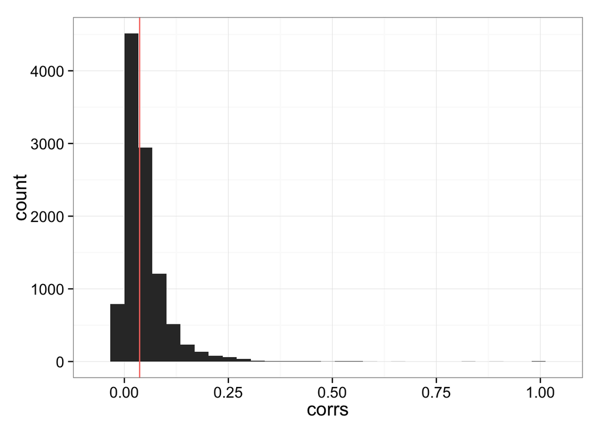

```r
ggplot(data.frame(corrs = corrs_vec ),
       aes(x = corrs) ) +
  geom_histogram() +
  geom_vline(data = data.frame(corr = dup_corrs$cor),
             aes(xintercept = corr,
                 colour = "red"),
             show_guide = FALSE)
```

### Gene-wise correction

```r
if (file.exists("../data/limma-crossed-per-gene.rda")) {
  load("../data/limma-crossed-per-gene.rda")
} else {
  gls_fit_per_gene <- Humanzee::ruv_mixed_model(molecules_cpm_trans,
                          ndups = 1,
                          per_gene = FALSE,
                          design = design, block = block,
                          correlation = corrs_vec)
  save(gls_fit_per_gene, file = "../data/limma-crossed-per-gene.rda")
}
```

Compute expression levels after removing variation due to random effects.

```r
molecules_final_per_gene <- t( design %*% t(gls_fit_per_gene$coef) ) + gls_fit_per_gene$resid
```

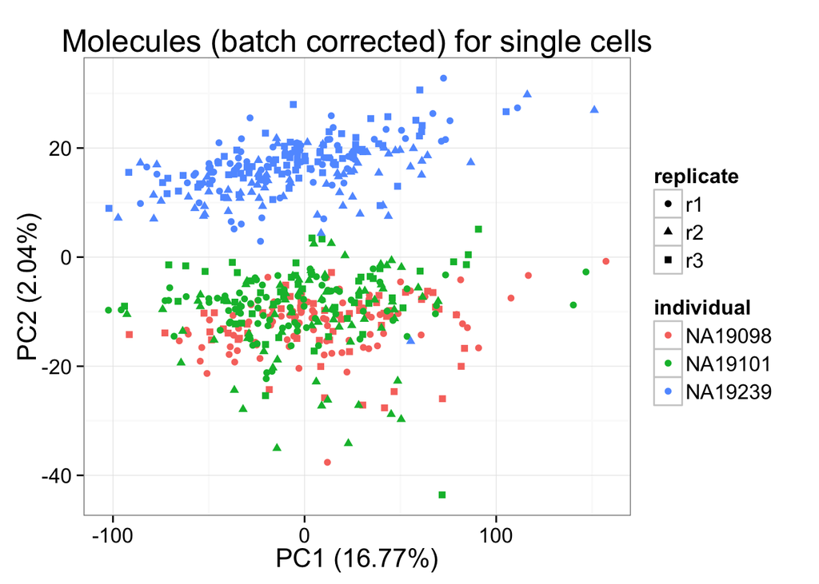

```r
pca_final_per_gene <- run_pca(molecules_final_per_gene)
pca_final_plot_per_gene <- plot_pca(pca_final_per_gene$PCs, explained = pca_final_per_gene$explained,
         metadata = anno_filter, color = "individual",
         shape = "replicate") +
  labs(title = "Molecules (batch corrected) for single cells")
pca_final_plot_per_gene
```

### Gene-wide correction

```r
if (file.exists("../data/limma-crossed.rda")) {
  load("../data/limma-crossed.rda")
} else {
  gls_fit <- Humanzee::ruv_mixed_model(molecules_cpm_trans,
                          ndups = 1,
                          per_gene = FALSE,
                          design = design, block = block,
                          correlation = dup_corrs$cor)
  save(gls_fit, file = "../data/limma-crossed.rda")
}
```

Compute expression levels after removing variation due to random effects.

```r
molecules_final <- t( design %*% t(gls_fit$coef) ) + gls_fit$resid
```

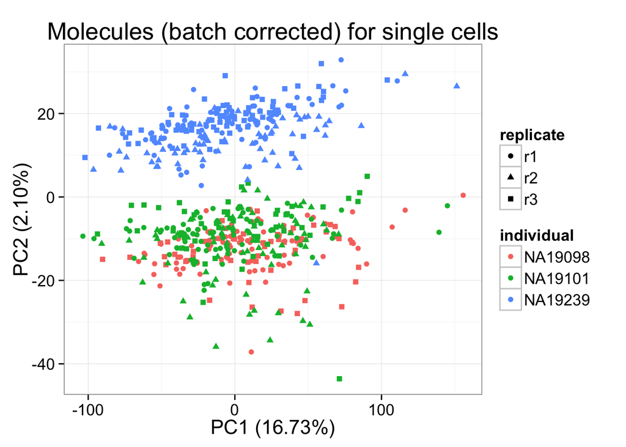

```r
pca_final <- run_pca(molecules_final)
pca_final_plot <- plot_pca(pca_final$PCs, explained = pca_final$explained,
         metadata = anno_filter, color = "individual",
         shape = "replicate") +
  labs(title = "Molecules (batch corrected) for single cells")
pca_final_plot
```

### Expression ranking

*Gene ranks per cell are consistent between the gene-wise correction and the gene-wide correction methods. There seems to be more fluctuations in the correlation between the two methods in cell ranks per gene, which suggests a possible impact on the analysis comparing coefficients of variations between genes.

Per-cell correlation in expression levels

```r
cell_corr <- sapply(1:NCOL(molecules_final), function(ii_cell) {
  cor(molecules_final[ , ii_cell],
      molecules_final_per_gene[ , ii_cell], method = "spearman")
})
summary(cell_corr)
```

```
   Min. 1st Qu.  Median    Mean 3rd Qu.    Max.
 0.9665  0.9958  0.9968  0.9964  0.9977  0.9992
```

Per-gene correlation in expression levels

```r
gene_corr <- sapply(1:NROW(molecules_final), function(ii_gene) {
  cor(molecules_final[ii_gene, ],
      molecules_final_per_gene[ii_gene, ], method = "spearman")
})
summary(gene_corr)
```

```
   Min. 1st Qu.  Median    Mean 3rd Qu.    Max.
 0.6550  0.9972  0.9990  0.9974  0.9998  1.0000
```

Per-gene correlation in expression levels for each individual

```r
gene_corr_individual <- lapply(1:3, function(ii_individual) {
  which_individual <- anno_filter$individual == unique(anno_filter$individual)[ii_individual]
  df <- molecules_final[ , which_individual]
  df_per_gene <- molecules_final_per_gene[ , which_individual]
  cell_corr <- sapply(1:NROW(molecules_final), function(ii_gene) {
          cor(df[ ii_gene, ],
              df_per_gene[ ii_gene, ], method = "spearman")
        })
  cell_corr
})
lapply(gene_corr_individual, summary)
```

```
[[1]]
   Min. 1st Qu.  Median    Mean 3rd Qu.    Max.
 0.7182  0.9974  0.9991  0.9973  0.9997  1.0000

[[2]]
   Min. 1st Qu.  Median    Mean 3rd Qu.    Max.
 0.8431  0.9969  0.9989  0.9971  0.9997  1.0000

[[3]]
   Min. 1st Qu.  Median    Mean 3rd Qu.    Max.
 0.5158  0.9972  0.9990  0.9971  0.9997  1.0000
```